# Predict Bike Sharing Demand with AutoGluon Template

## Project: Predict Bike Sharing Demand with AutoGluon

This notebook is a template with each step that you need to complete for the project.

Please fill in your code where there are explicit `?` markers in the notebook. You are welcome to add more cells and code as you see fit.

Once you have completed all the code implementations, please export your notebook as a HTML file so the reviews can view your code. Make sure you have all outputs correctly outputted.

`File-> Export Notebook As... -> Export Notebook as HTML`

There is a writeup to complete as well after all code implememtation is done. Please answer all questions and attach the necessary tables and charts. You can complete the writeup in either markdown or PDF.

Completing the code template and writeup template will cover all of the rubric points for this project.

The rubric contains "Stand Out Suggestions" for enhancing the project beyond the minimum requirements. The stand out suggestions are optional. If you decide to pursue the "stand out suggestions", you can include the code in this notebook and also discuss the results in the writeup file.

## Step 1: Create an account with Kaggle

### Create Kaggle Account and download API key

Below is example of steps to get the API username and key. Each student will have their own username and key.

1. Open account settings.

2. Scroll down to API and click Create New API Token.

3. Open up `kaggle.json` and use the username and key.

## Step 2: Download the Kaggle dataset using the kaggle python library

### Open up Sagemaker Studio and use starter template

1. Notebook should be using a `ml.t3.medium` instance (2 vCPU + 4 GiB)
2. Notebook should be using kernal: `Python 3 (MXNet 1.8 Python 3.7 CPU Optimized)`

### Install packages

```python
!pip install -U pip
!pip install -U setuptools wheel
!pip install -U "mxnet<2.0.0" bokeh==2.0.1
!pip install autogluon --no-cache-dir
# Without --no-cache-dir, smaller aws instances may have trouble installing
```

```python
!pip install kaggle
```

```
  Preparing metadata (setup.py) ... done
```

```python
%pwd
```

```
'/home/sagemaker-user/proj1/cd0385-project-starter/project'
```

```python
!mkdir -p /home/sagemaker-user/.config/kaggle
```

### Setup Kaggle API Key

```python
!touch /home/sagemaker-user/.config/kaggle/kaggle.json
!chmod 600 /home/sagemaker-user/.config/kaggle/kaggle.json
```

```python
# Fill in your user name and key from creating the kaggle account and API token file
import json
kaggle_username = "<submissionmask>"
kaggle_key = "<submissionmask>"

# Save API token the kaggle.json file
with open("/home/sagemaker-user/.config/kaggle/kaggle.json", "w") as f:
    f.write(json.dumps({"username": kaggle_username, "key": kaggle_key}))
```

### Download and explore dataset

### Go to the bike sharing demand competition and agree to the terms

```python
# Download the dataset, it will be in a .zip file so you'll need to unzip it as well.
!kaggle competitions download -c bike-sharing-demand
# If you already downloaded it you can use the -o command to overwrite the file
!unzip -o bike-sharing-demand.zip
```

```
Downloading bike-sharing-demand.zip to /home/sagemaker-user/proj1/cd0385-project-starter/project
Archive:  bike-sharing-demand.zip
  inflating: sampleSubmission.csv
  inflating: test.csv
  inflating: train.csv
```

```python
!ls -ltr
```

```
total 4520
-rw-r--r-- 1 sagemaker-user users  648353 Dec 11  2019 train.csv
-rw-r--r-- 1 sagemaker-user users  323856 Dec 11  2019 test.csv
-rw-r--r-- 1 sagemaker-user users  142861 Dec 11  2019 sampleSubmission.csv
-rw-r--r-- 1 sagemaker-user users  193828 Dec 11  2019 bike-sharing-demand.zip
drwxr-xr-x 2 sagemaker-user users     129 Nov  2 01:53 img
-rw-r--r-- 1 sagemaker-user users    3487 Nov  2 01:53 README.md
-rw-r--r-- 1 sagemaker-user users    1573 Nov  2 01:53 report-template.md
-rw-r--r-- 1 sagemaker-user users 1626181 Nov  2 01:54 project-template-orig.ipynb
drwxr-xr-x 3 sagemaker-user users      21 Nov  2 02:03 root
-rw-r--r-- 1 sagemaker-user users 1669832 Nov  2 02:11 project-template.ipynb
```

```python
import pandas as pd
from autogluon.tabular import TabularPredictor
```

```python
# Create the train dataset in pandas by reading the csv
# Set the parsing of the datetime column so you can use some of the `dt` features in pandas later
train = pd.read_csv('./train.csv')
train.head()
```

|  | datetime | season | holiday | workingday | weather | temp | atemp | humidity | windspeed | casual | registered | count |
| --- | --- | --- | --- | --- | --- | --- | --- | --- | --- | --- | --- | --- |
| 0 | 2011-01-01 00:00:00 | 1 | 0 | 0 | 1 | 9.84 | 14.395 | 81 | 0.0 | 3 | 13 | 16 |
| 1 | 2011-01-01 01:00:00 | 1 | 0 | 0 | 1 | 9.02 | 13.635 | 80 | 0.0 | 8 | 32 | 40 |
| 2 | 2011-01-01 02:00:00 | 1 | 0 | 0 | 1 | 9.02 | 13.635 | 80 | 0.0 | 5 | 27 | 32 |
| 3 | 2011-01-01 03:00:00 | 1 | 0 | 0 | 1 | 9.84 | 14.395 | 75 | 0.0 | 3 | 10 | 13 |
| 4 | 2011-01-01 04:00:00 | 1 | 0 | 0 | 1 | 9.84 | 14.395 | 75 | 0.0 | 0 | 1 | 1 |

```python
train['datetime'] = pd.to_datetime(train['datetime'])
train.info()
```

```
<class 'pandas.core.frame.DataFrame'>
RangeIndex: 10886 entries, 0 to 10885
Data columns (total 12 columns):
 #   Column      Non-Null Count  Dtype
---  ------      --------------  -----
 0   datetime    10886 non-null  datetime64[ns]
 1   season      10886 non-null  int64
 2   holiday     10886 non-null  int64
 3   workingday  10886 non-null  int64
 4   weather     10886 non-null  int64
 5   temp        10886 non-null  float64
 6   atemp       10886 non-null  float64
 7   humidity    10886 non-null  int64
 8   windspeed   10886 non-null  float64
 9   casual      10886 non-null  int64
 10  registered  10886 non-null  int64
 11  count       10886 non-null  int64
dtypes: datetime64[ns](1), float64(3), int64(8)
memory usage: 1020.7 KB
```

```python
# Simple output of the train dataset to view some of the min/max/varition of the dataset features.
train.describe()
```

|  | datetime | season | holiday | workingday | weather | temp | atemp | humidity | windspeed | casual | registered | count |
| --- | --- | --- | --- | --- | --- | --- | --- | --- | --- | --- | --- | --- |
| count | 10886 | 10886.000000 | 10886.000000 | 10886.000000 | 10886.000000 | 10886.00000 | 10886.000000 | 10886.000000 | 10886.000000 | 10886.000000 | 10886.000000 | 10886.000000 |
| mean | 2011-12-27 05:56:22.399411968 | 2.506614 | 0.028569 | 0.680875 | 1.418427 | 20.23086 | 23.655084 | 61.886460 | 12.799395 | 36.021955 | 155.552177 | 191.574132 |
| min | 2011-01-01 00:00:00 | 1.000000 | 0.000000 | 0.000000 | 1.000000 | 0.82000 | 0.760000 | 0.000000 | 0.000000 | 0.000000 | 0.000000 | 1.000000 |
| 25% | 2011-07-02 07:15:00 | 2.000000 | 0.000000 | 0.000000 | 1.000000 | 13.94000 | 16.665000 | 47.000000 | 7.001500 | 4.000000 | 36.000000 | 42.000000 |
| 50% | 2012-01-01 20:30:00 | 3.000000 | 0.000000 | 1.000000 | 1.000000 | 20.50000 | 24.240000 | 62.000000 | 12.998000 | 17.000000 | 118.000000 | 145.000000 |
| 75% | 2012-07-01 12:45:00 | 4.000000 | 0.000000 | 1.000000 | 2.000000 | 26.24000 | 31.060000 | 77.000000 | 16.997900 | 49.000000 | 222.000000 | 284.000000 |
| max | 2012-12-19 23:00:00 | 4.000000 | 1.000000 | 1.000000 | 4.000000 | 41.00000 | 45.455000 | 100.000000 | 56.996900 | 367.000000 | 886.000000 | 977.000000 |
| std | NaN | 1.116174 | 0.166599 | 0.466159 | 0.633839 | 7.79159 | 8.474601 | 19.245033 | 8.164537 | 49.960477 | 151.039033 | 181.144454 |

```python
# Create the test pandas dataframe in pandas by reading the csv, remember to parse the datetime!
test = pd.read_csv('./test.csv')
test.head()
```

|  | datetime | season | holiday | workingday | weather | temp | atemp | humidity | windspeed |
| --- | --- | --- | --- | --- | --- | --- | --- | --- | --- |
| 0 | 2011-01-20 00:00:00 | 1 | 0 | 1 | 1 | 10.66 | 11.365 | 56 | 26.0027 |
| 1 | 2011-01-20 01:00:00 | 1 | 0 | 1 | 1 | 10.66 | 13.635 | 56 | 0.0000 |
| 2 | 2011-01-20 02:00:00 | 1 | 0 | 1 | 1 | 10.66 | 13.635 | 56 | 0.0000 |
| 3 | 2011-01-20 03:00:00 | 1 | 0 | 1 | 1 | 10.66 | 12.880 | 56 | 11.0014 |
| 4 | 2011-01-20 04:00:00 | 1 | 0 | 1 | 1 | 10.66 | 12.880 | 56 | 11.0014 |

```python
test.info()
```

```
<class 'pandas.core.frame.DataFrame'>
RangeIndex: 6493 entries, 0 to 6492
Data columns (total 9 columns):
 #   Column      Non-Null Count  Dtype
---  ------      --------------  -----
 0   datetime    6493 non-null   object
 1   season      6493 non-null   int64
 2   holiday     6493 non-null   int64
 3   workingday  6493 non-null   int64
 4   weather     6493 non-null   int64
 5   temp        6493 non-null   float64
 6   atemp       6493 non-null   float64
 7   humidity    6493 non-null   int64
 8   windspeed   6493 non-null   float64
dtypes: float64(3), int64(5), object(1)
memory usage: 456.7+ KB
```

```python
test['datetime'] = pd.to_datetime(test['datetime'])
test.info()
```

```
<class 'pandas.core.frame.DataFrame'>
RangeIndex: 6493 entries, 0 to 6492
Data columns (total 9 columns):
 #   Column      Non-Null Count  Dtype
---  ------      --------------  -----
 0   datetime    6493 non-null   datetime64[ns]
 1   season      6493 non-null   int64
 2   holiday     6493 non-null   int64
 3   workingday  6493 non-null   int64
 4   weather     6493 non-null   int64
 5   temp        6493 non-null   float64
 6   atemp       6493 non-null   float64
 7   humidity    6493 non-null   int64
 8   windspeed   6493 non-null   float64
dtypes: datetime64[ns](1), float64(3), int64(5)
memory usage: 456.7 KB
```

```python
# Same thing as train and test dataset
submission = pd.read_csv('sampleSubmission.csv')
submission.head()
```

|  | datetime | count |
| --- | --- | --- |
| 0 | 2011-01-20 00:00:00 | 0 |
| 1 | 2011-01-20 01:00:00 | 0 |
| 2 | 2011-01-20 02:00:00 | 0 |
| 3 | 2011-01-20 03:00:00 | 0 |
| 4 | 2011-01-20 04:00:00 | 0 |

```python
submission.info()
```

```
<class 'pandas.core.frame.DataFrame'>
RangeIndex: 6493 entries, 0 to 6492
Data columns (total 2 columns):
 #   Column    Non-Null Count  Dtype
---  ------    --------------  -----
 0   datetime  6493 non-null   object
 1   count     6493 non-null   int64
dtypes: int64(1), object(1)
memory usage: 101.6+ KB
```

```python
submission['datetime'] = pd.to_datetime(submission['datetime'])
submission.info()
```

```
<class 'pandas.core.frame.DataFrame'>
RangeIndex: 6493 entries, 0 to 6492
Data columns (total 2 columns):
 #   Column    Non-Null Count  Dtype
---  ------    --------------  -----
 0   datetime  6493 non-null   datetime64[ns]
 1   count     6493 non-null   int64
dtypes: datetime64[ns](1), int64(1)
memory usage: 101.6 KB
```

## Step 3: Train a model using AutoGluon’s Tabular Prediction

Requirements:

- We are prediting `count`, so it is the label we are setting.
- Ignore `casual` and `registered` columns as they are also not present in the test dataset.
- Use the `root_mean_squared_error` as the metric to use for evaluation.
- Set a time limit of 10 minutes (600 seconds).
- Use the preset `best_quality` to focus on creating the best model.

```python
train.columns, test.columns
```

```
(Index(['datetime', 'season', 'holiday', 'workingday', 'weather', 'temp',
        'atemp', 'humidity', 'windspeed', 'casual', 'registered', 'count'],
       dtype='object'),
 Index(['datetime', 'season', 'holiday', 'workingday', 'weather', 'temp',
        'atemp', 'humidity', 'windspeed'],
       dtype='object'))
```

```python
cols = list(train.columns)
cols.remove('casual')
cols.remove('registered')
cols
```

```
['datetime',
 'season',
 'holiday',
 'workingday',
 'weather',
 'temp',
 'atemp',
 'humidity',
 'windspeed',
 'count']
```

```python
df_train = train[cols].copy()
df_train
```

|  | datetime | season | holiday | workingday | weather | temp | atemp | humidity | windspeed | count |
| --- | --- | --- | --- | --- | --- | --- | --- | --- | --- | --- |
| 0 | 2011-01-01 00:00:00 | 1 | 0 | 0 | 1 | 9.84 | 14.395 | 81 | 0.0000 | 16 |
| 1 | 2011-01-01 01:00:00 | 1 | 0 | 0 | 1 | 9.02 | 13.635 | 80 | 0.0000 | 40 |
| 2 | 2011-01-01 02:00:00 | 1 | 0 | 0 | 1 | 9.02 | 13.635 | 80 | 0.0000 | 32 |
| 3 | 2011-01-01 03:00:00 | 1 | 0 | 0 | 1 | 9.84 | 14.395 | 75 | 0.0000 | 13 |
| 4 | 2011-01-01 04:00:00 | 1 | 0 | 0 | 1 | 9.84 | 14.395 | 75 | 0.0000 | 1 |
| ... | ... | ... | ... | ... | ... | ... | ... | ... | ... | ... |
| 10881 | 2012-12-19 19:00:00 | 4 | 0 | 1 | 1 | 15.58 | 19.695 | 50 | 26.0027 | 336 |
| 10882 | 2012-12-19 20:00:00 | 4 | 0 | 1 | 1 | 14.76 | 17.425 | 57 | 15.0013 | 241 |
| 10883 | 2012-12-19 21:00:00 | 4 | 0 | 1 | 1 | 13.94 | 15.910 | 61 | 15.0013 | 168 |
| 10884 | 2012-12-19 22:00:00 | 4 | 0 | 1 | 1 | 13.94 | 17.425 | 61 | 6.0032 | 129 |
| 10885 | 2012-12-19 23:00:00 | 4 | 0 | 1 | 1 | 13.12 | 16.665 | 66 | 8.9981 | 88 |

10886 rows × 10 columns

```python
%%time
predictor = TabularPredictor(label='count', problem_type='regression', eval_metric='root_mean_squared_error').fit(
    train_data=df_train, time_limit=600, presets="best_quality")
```

[output not shown]

[output cut: 41 more lines]

[output not shown]

```
(_ray_fit pid=1253) [1000]	valid_set's rmse: 129.692
```

[output not shown]

```
(_ray_fit pid=1377) [2000]	valid_set's rmse: 126.702 [repeated 7x across cluster]
(_ray_fit pid=1410) [5000]	valid_set's rmse: 132.706 [repeated 15x across cluster]
```

[output not shown]

```
(_ray_fit pid=1504) [1000]	valid_set's rmse: 129.285 [repeated 15x across cluster]
```

[output not shown]

```
(_ray_fit pid=1619) [1000]	valid_set's rmse: 134.058 [repeated 4x across cluster]
```

[output not shown]

```
(_ray_fit pid=2361) [1000]	valid_set's rmse: 69.1061 [repeated 3x across cluster]
```

[output not shown]

```
(_ray_fit pid=2481) [1000]	valid_set's rmse: 75.2022 [repeated 5x across cluster]
```

[output not shown]

[output cut: 159 more lines]

```
	-51.459	 = Validation score   (-root_mean_squared_error)
	31.79s	 = Training   runtime
	0.21s	 = Validation runtime
Fitting model: XGBoost_BAG_L2 ... Training model for up to 4.69s of the 4.66s of remaining time.
	Fitting 8 child models (S1F1 - S1F8) | Fitting with ParallelLocalFoldFittingStrategy (4 workers, per: cpus=1, gpus=0, memory=0.50%)
	-55.1322	 = Validation score   (-root_mean_squared_error)
	6.83s	 = Training   runtime
	0.1s	 = Validation runtime
Fitting model: WeightedEnsemble_L3 ... Training model for up to 360.0s of the -5.37s of remaining time.
	Ensemble Weights: {'NeuralNetFastAI_BAG_L2': 0.6, 'RandomForestMSE_BAG_L2': 0.267, 'ExtraTreesMSE_BAG_L2': 0.133}
	-50.3661	 = Validation score   (-root_mean_squared_error)
	0.04s	 = Training   runtime
	0.0s	 = Validation runtime
AutoGluon training complete, total runtime = 446.11s ... Best model: WeightedEnsemble_L3 | Estimated inference throughput: 156.5 rows/s (1361 batch size)
TabularPredictor saved. To load, use: predictor = TabularPredictor.load("AutogluonModels/ag-20241102_022235")
```

```
CPU times: user 2min 9s, sys: 2.87 s, total: 2min 12s
Wall time: 10min 5s
```

### Review AutoGluon's training run with ranking of models that did the best.

```python
predictor.fit_summary()
```

```
*** Summary of fit() ***
Estimated performance of each model:
                     model   score_val              eval_metric  pred_time_val    fit_time  pred_time_val_marginal  fit_time_marginal  stack_level  can_infer  fit_order
0      WeightedEnsemble_L3  -50.366096  root_mean_squared_error      10.511206  332.238751                0.000464           0.036729            3       True         20
1   NeuralNetFastAI_BAG_L2  -51.459005  root_mean_squared_error       9.452260  307.776511                0.207894          31.790681            2       True         18
2   RandomForestMSE_BAG_L2  -53.355419  root_mean_squared_error       9.774369  295.331128                0.530003          19.345298            2       True         15
3     ExtraTreesMSE_BAG_L2  -53.898623  root_mean_squared_error       9.772845  281.066044                0.528479           5.080213            2       True         17
4          LightGBM_BAG_L2  -54.866191  root_mean_squared_error       9.459404  284.335892                0.215038           8.350061            2       True         14
5           XGBoost_BAG_L2  -55.132173  root_mean_squared_error       9.349191  282.817328                0.104824           6.831498            2       True         19
6          CatBoost_BAG_L2  -55.622830  root_mean_squared_error       9.303210  319.992028                0.058844          44.006198            2       True         16
7        LightGBMXT_BAG_L2  -60.396676  root_mean_squared_error      11.857606  293.857356                2.613240          17.871526            2       True         13
8    KNeighborsDist_BAG_L1  -84.125061  root_mean_squared_error       0.026527    0.025528                0.026527           0.025528            1       True          2
9      WeightedEnsemble_L2  -84.125061  root_mean_squared_error       0.026989    0.053084                0.000462           0.027556            2       True         12
10   KNeighborsUnif_BAG_L1 -101.546199  root_mean_squared_error       0.037880    0.028678                0.037880           0.028678            1       True          1
11  RandomForestMSE_BAG_L1 -116.548359  root_mean_squared_error       0.479065    6.078726                0.479065           6.078726            1       True          5
12    ExtraTreesMSE_BAG_L1 -124.600676  root_mean_squared_error       0.470767    2.787814                0.470767           2.787814            1       True          7
13    LightGBMLarge_BAG_L1 -130.132290  root_mean_squared_error       0.879333   10.189317                0.879333          10.189317            1       True         11
14         CatBoost_BAG_L1 -130.461205  root_mean_squared_error       0.076654  109.862751                0.076654         109.862751            1       True          6
15         LightGBM_BAG_L1 -131.054162  root_mean_squared_error       1.420314    9.098561                1.420314           9.098561            1       True          4
16       LightGBMXT_BAG_L1 -131.460909  root_mean_squared_error       5.064735   23.051226                5.064735          23.051226            1       True          3
17          XGBoost_BAG_L1 -131.893935  root_mean_squared_error       0.422446    7.207176                0.422446           7.207176            1       True          9
18  NeuralNetFastAI_BAG_L1 -136.203809  root_mean_squared_error       0.251787   31.425534                0.251787          31.425534            1       True          8
19   NeuralNetTorch_BAG_L1 -138.878322  root_mean_squared_error       0.114858   76.230520                0.114858          76.230520            1       True         10
Number of models trained: 20
Types of models trained:
{'StackerEnsembleModel_RF', 'StackerEnsembleModel_LGB', 'WeightedEnsembleModel', 'StackerEnsembleModel_TabularNeuralNetTorch', 'StackerEnsembleModel_NNFastAiTabular', 'StackerEnsembleModel_XGBoost', 'StackerEnsembleModel_KNN', 'StackerEnsembleModel_XT', 'StackerEnsembleModel_CatBoost'}
Bagging used: True  (with 8 folds)
Multi-layer stack-ensembling used: True  (with 3 levels)
Feature Metadata (Processed):
(raw dtype, special dtypes):
('float', [])                : 3 | ['temp', 'atemp', 'windspeed']
('int', [])                  : 3 | ['season', 'weather', 'humidity']
('int', ['bool'])            : 2 | ['holiday', 'workingday']
('int', ['datetime_as_int']) : 5 | ['datetime', 'datetime.year', 'datetime.month', 'datetime.day', 'datetime.dayofweek']
*** End of fit() summary ***
```

[output not shown]

[output cut: 199 more lines]

```
 5             2       True         19
 6             2       True         16
 7             2       True         13
 8             1       True          2
 9             2       True         12
 10            1       True          1
 11            1       True          5
 12            1       True          7
 13            1       True         11
 14            1       True          6
 15            1       True          4
 16            1       True          3
 17            1       True          9
 18            1       True          8
 19            1       True         10  }
```

### Create predictions from test dataset

```python
predictions = predictor.predict(test)
predictions.head()
```

```
0    25.056583
1    40.831757
2    45.028233
3    47.731026
4    50.344528
Name: count, dtype: float32
```

#### NOTE: Kaggle will reject the submission if we don't set everything to be > 0.

```python
# Describe the `predictions` series to see if there are any negative values
predictions.describe()
```

```
count    6493.000000
mean      101.298637
std        88.680916
min         1.460654
25%        24.404367
50%        68.376228
75%       170.202591
max       351.429077
Name: count, dtype: float64
```

```python
# How many negative values do we have?
(predictions < 0).sum()
```

```
0
```

```python
# Set them to zero
# Note: As can be seen from outputs shown above, there are no negative values
predictions
```

```
0        25.056583
1        40.831757
2        45.028233
3        47.731026
4        50.344528
           ...
6488    176.699341
6489    176.703552
6490    166.519836
6491    156.809601
6492    158.391907
Name: count, Length: 6493, dtype: float32
```

### Set predictions to submission dataframe, save, and submit

```python
submission["count"] = predictions
submission.to_csv("submission.csv", index=False)
```

```python
!kaggle competitions submit -c bike-sharing-demand -f submission.csv -m "first raw submission"
```

```
Successfully submitted to Bike Sharing Demand
```

#### View submission via the command line or in the web browser under the competition's page - `My Submissions`

```python
!kaggle competitions submissions -c bike-sharing-demand | head -3
```

```
fileName                     date                 description                        status    publicScore  privateScore
---------------------------  -------------------  ---------------------------------  --------  -----------  ------------
submission.csv               2024-11-02 02:39:49  first raw submission               complete  1.77860      1.77860
```

#### Initial score of `1.77860`

## Step 4: Exploratory Data Analysis and Creating an additional feature

- Any additional feature will do, but a great suggestion would be to separate out the datetime into hour, day, or month parts.

```python
import matplotlib.pyplot as plt
```

```python
# Create a histogram of all features to show the distribution of each one relative to the data. This is part of the exploratory data analysis
train.info()
```

```
<class 'pandas.core.frame.DataFrame'>
RangeIndex: 10886 entries, 0 to 10885
Data columns (total 12 columns):
 #   Column      Non-Null Count  Dtype
---  ------      --------------  -----
 0   datetime    10886 non-null  datetime64[ns]
 1   season      10886 non-null  int64
 2   holiday     10886 non-null  int64
 3   workingday  10886 non-null  int64
 4   weather     10886 non-null  int64
 5   temp        10886 non-null  float64
 6   atemp       10886 non-null  float64
 7   humidity    10886 non-null  int64
 8   windspeed   10886 non-null  float64
 9   casual      10886 non-null  int64
 10  registered  10886 non-null  int64
 11  count       10886 non-null  int64
dtypes: datetime64[ns](1), float64(3), int64(8)
memory usage: 1020.7 KB
```

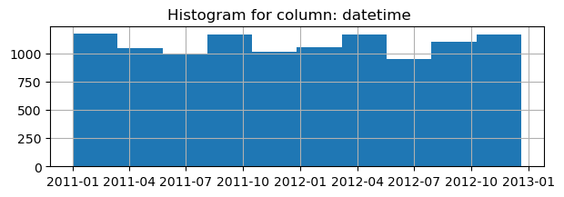

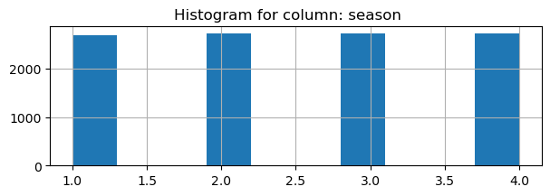

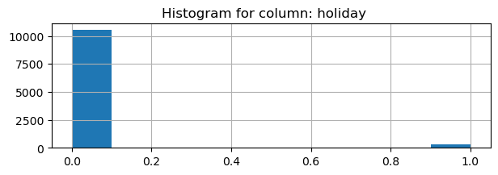

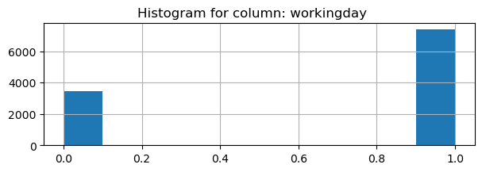

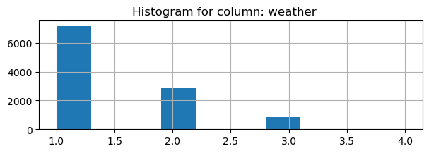

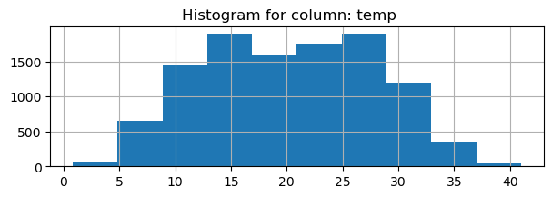

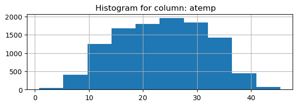

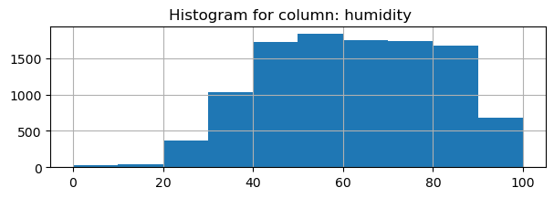

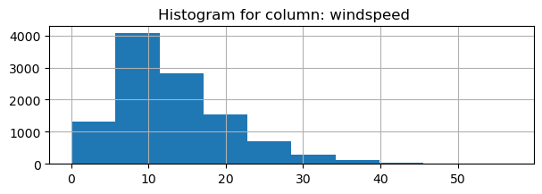

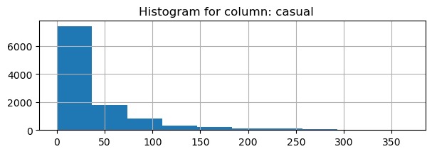

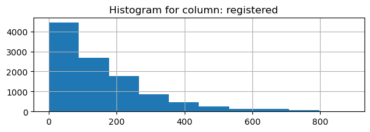

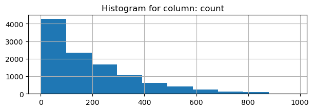

```python
# Create a histogram of all features to show the distribution of each one relative to the data. This is part of the exploritory data analysis
plt.figure(figsize=(5,2))
for i in train.columns:
    plt.figure(figsize=(7,2))
    train[i].hist()
    plt.suptitle(f'Histogram for column: {i}')
    plt.show()
```

```python
# create a new feature
train['date'] = train['datetime'].dt.day
train['month'] = train['datetime'].dt.month
train['hour'] = train['datetime'].dt.hour

test['date'] = test['datetime'].dt.day
test['month'] = test['datetime'].dt.month
test['hour'] = test['datetime'].dt.hour
```

## Make category types for these so models know they are not just numbers

- AutoGluon originally sees these as ints, but in reality they are int representations of a category.
- Setting the dtype to category will classify these as categories in AutoGluon.

```python
train["season"] = train['season'].astype('category')
train["weather"] = train['weather'].astype('category')
test["season"] = test['season'].astype('category')
test["weather"] = test['weather'].astype('category')
```

```python
train.info()
```

```
<class 'pandas.core.frame.DataFrame'>
RangeIndex: 10886 entries, 0 to 10885
Data columns (total 15 columns):
 #   Column      Non-Null Count  Dtype
---  ------      --------------  -----
 0   datetime    10886 non-null  datetime64[ns]
 1   season      10886 non-null  category
 2   holiday     10886 non-null  int64
 3   workingday  10886 non-null  int64
 4   weather     10886 non-null  category
 5   temp        10886 non-null  float64
 6   atemp       10886 non-null  float64
 7   humidity    10886 non-null  int64
 8   windspeed   10886 non-null  float64
 9   casual      10886 non-null  int64
 10  registered  10886 non-null  int64
 11  count       10886 non-null  int64
 12  date        10886 non-null  int32
 13  month       10886 non-null  int32
 14  hour        10886 non-null  int32
dtypes: category(2), datetime64[ns](1), float64(3), int32(3), int64(6)
memory usage: 999.8 KB
```

```python
test.info()
```

```
<class 'pandas.core.frame.DataFrame'>
RangeIndex: 6493 entries, 0 to 6492
Data columns (total 12 columns):
 #   Column      Non-Null Count  Dtype
---  ------      --------------  -----
 0   datetime    6493 non-null   datetime64[ns]
 1   season      6493 non-null   category
 2   holiday     6493 non-null   int64
 3   workingday  6493 non-null   int64
 4   weather     6493 non-null   category
 5   temp        6493 non-null   float64
 6   atemp       6493 non-null   float64
 7   humidity    6493 non-null   int64
 8   windspeed   6493 non-null   float64
 9   date        6493 non-null   int32
 10  month       6493 non-null   int32
 11  hour        6493 non-null   int32
dtypes: category(2), datetime64[ns](1), float64(3), int32(3), int64(3)
memory usage: 444.4 KB
```

```python
# View  new features
train.head()
```

|  | datetime | season | holiday | workingday | weather | temp | atemp | humidity | windspeed | casual | registered | count | date | month | hour |
| --- | --- | --- | --- | --- | --- | --- | --- | --- | --- | --- | --- | --- | --- | --- | --- |
| 0 | 2011-01-01 00:00:00 | 1 | 0 | 0 | 1 | 9.84 | 14.395 | 81 | 0.0 | 3 | 13 | 16 | 1 | 1 | 0 |
| 1 | 2011-01-01 01:00:00 | 1 | 0 | 0 | 1 | 9.02 | 13.635 | 80 | 0.0 | 8 | 32 | 40 | 1 | 1 | 1 |
| 2 | 2011-01-01 02:00:00 | 1 | 0 | 0 | 1 | 9.02 | 13.635 | 80 | 0.0 | 5 | 27 | 32 | 1 | 1 | 2 |
| 3 | 2011-01-01 03:00:00 | 1 | 0 | 0 | 1 | 9.84 | 14.395 | 75 | 0.0 | 3 | 10 | 13 | 1 | 1 | 3 |
| 4 | 2011-01-01 04:00:00 | 1 | 0 | 0 | 1 | 9.84 | 14.395 | 75 | 0.0 | 0 | 1 | 1 | 1 | 1 | 4 |

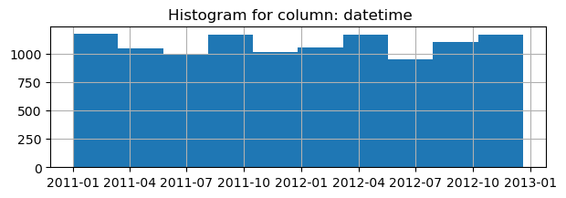

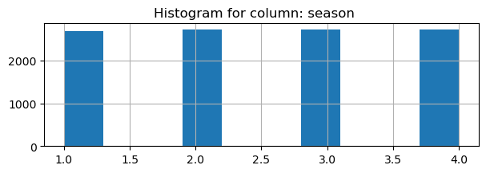

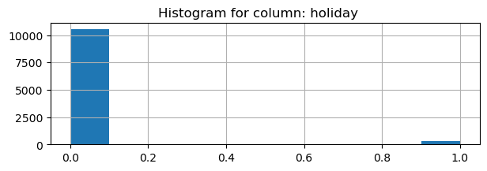

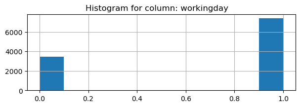

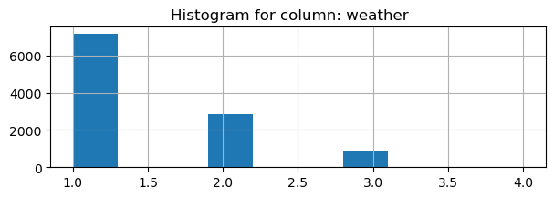

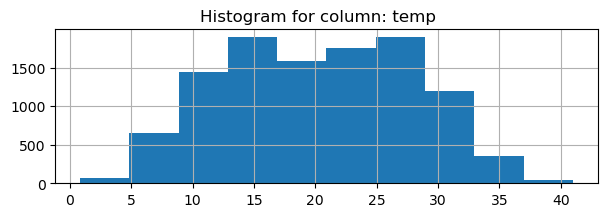

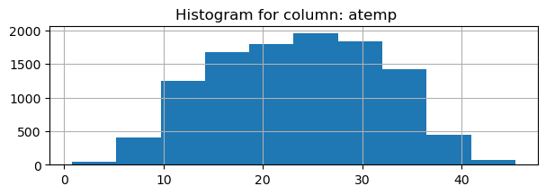

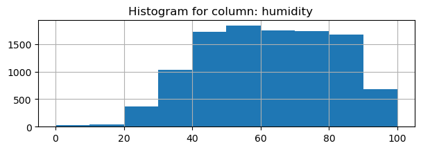

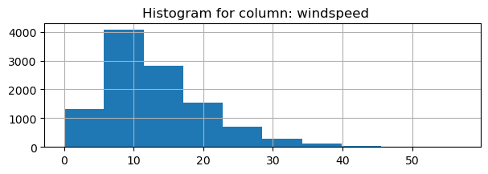

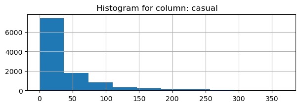

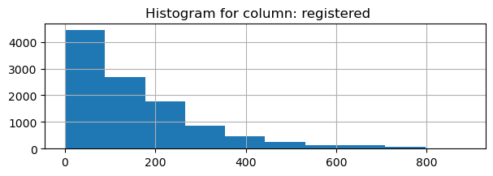

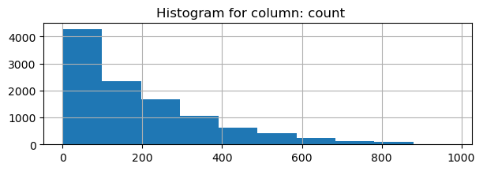

[3 more figures not shown]

```python
# View histogram of all features again now with the hour feature
plt.figure(figsize=(5,2))
for i in train.columns:
    plt.figure(figsize=(7,2))
    train[i].hist()
    plt.suptitle(f'Histogram for column: {i}')
    plt.show()
```

## Step 5: Rerun the model with the same settings as before, just with more features

```python
cols = list(train.columns)
cols.remove('casual')
cols.remove('registered')
cols

df_train = train[cols].copy()
df_train
```

|  | datetime | season | holiday | workingday | weather | temp | atemp | humidity | windspeed | count | date | month | hour |
| --- | --- | --- | --- | --- | --- | --- | --- | --- | --- | --- | --- | --- | --- |
| 0 | 2011-01-01 00:00:00 | 1 | 0 | 0 | 1 | 9.84 | 14.395 | 81 | 0.0000 | 16 | 1 | 1 | 0 |
| 1 | 2011-01-01 01:00:00 | 1 | 0 | 0 | 1 | 9.02 | 13.635 | 80 | 0.0000 | 40 | 1 | 1 | 1 |
| 2 | 2011-01-01 02:00:00 | 1 | 0 | 0 | 1 | 9.02 | 13.635 | 80 | 0.0000 | 32 | 1 | 1 | 2 |
| 3 | 2011-01-01 03:00:00 | 1 | 0 | 0 | 1 | 9.84 | 14.395 | 75 | 0.0000 | 13 | 1 | 1 | 3 |
| 4 | 2011-01-01 04:00:00 | 1 | 0 | 0 | 1 | 9.84 | 14.395 | 75 | 0.0000 | 1 | 1 | 1 | 4 |
| ... | ... | ... | ... | ... | ... | ... | ... | ... | ... | ... | ... | ... | ... |
| 10881 | 2012-12-19 19:00:00 | 4 | 0 | 1 | 1 | 15.58 | 19.695 | 50 | 26.0027 | 336 | 19 | 12 | 19 |
| 10882 | 2012-12-19 20:00:00 | 4 | 0 | 1 | 1 | 14.76 | 17.425 | 57 | 15.0013 | 241 | 19 | 12 | 20 |
| 10883 | 2012-12-19 21:00:00 | 4 | 0 | 1 | 1 | 13.94 | 15.910 | 61 | 15.0013 | 168 | 19 | 12 | 21 |
| 10884 | 2012-12-19 22:00:00 | 4 | 0 | 1 | 1 | 13.94 | 17.425 | 61 | 6.0032 | 129 | 19 | 12 | 22 |
| 10885 | 2012-12-19 23:00:00 | 4 | 0 | 1 | 1 | 13.12 | 16.665 | 66 | 8.9981 | 88 | 19 | 12 | 23 |

10886 rows × 13 columns

```python
predictor_new_features = TabularPredictor(
    label='count', problem_type='regression', eval_metric='root_mean_squared_error').fit(
    train_data=df_train, time_limit=600, presets="best_quality")
```

[output not shown]

[output cut: 120 more lines]

```
	-31.3969	 = Validation score   (-root_mean_squared_error)
	4.97s	 = Training   runtime
	0.54s	 = Validation runtime
Fitting model: NeuralNetFastAI_BAG_L2 ... Training model for up to 22.42s of the 22.4s of remaining time.
	Fitting 8 child models (S1F1 - S1F8) | Fitting with ParallelLocalFoldFittingStrategy (4 workers, per: cpus=1, gpus=0, memory=0.28%)
	-30.4758	 = Validation score   (-root_mean_squared_error)
	26.33s	 = Training   runtime
	0.4s	 = Validation runtime
Fitting model: WeightedEnsemble_L3 ... Training model for up to 360.0s of the -6.41s of remaining time.
	Ensemble Weights: {'CatBoost_BAG_L2': 0.381, 'NeuralNetFastAI_BAG_L2': 0.381, 'LightGBM_BAG_L2': 0.238}
	-29.7718	 = Validation score   (-root_mean_squared_error)
	0.05s	 = Training   runtime
	0.0s	 = Validation runtime
AutoGluon training complete, total runtime = 445.57s ... Best model: WeightedEnsemble_L3 | Estimated inference throughput: 91.4 rows/s (1361 batch size)
TabularPredictor saved. To load, use: predictor = TabularPredictor.load("AutogluonModels/ag-20241102_025150")
```

```python
predictor_new_features.fit_summary()
```

```
*** Summary of fit() ***
Estimated performance of each model:
                     model   score_val              eval_metric  pred_time_val    fit_time  pred_time_val_marginal  fit_time_marginal  stack_level  can_infer  fit_order
0      WeightedEnsemble_L3  -29.771775  root_mean_squared_error      15.818464  386.853532                0.000659           0.045092            3       True         16
1          CatBoost_BAG_L2  -30.231832  root_mean_squared_error      15.175244  351.472527                0.089786          71.145153            2       True         13
2   NeuralNetFastAI_BAG_L2  -30.475849  root_mean_squared_error      15.485028  306.660672                0.399569          26.333298            2       True         15
3          LightGBM_BAG_L2  -30.532328  root_mean_squared_error      15.328450  289.329989                0.242992           9.002615            2       True         11
4        LightGBMXT_BAG_L2  -30.986415  root_mean_squared_error      16.194464  291.452124                1.109006          11.124750            2       True         10
5     ExtraTreesMSE_BAG_L2  -31.396879  root_mean_squared_error      15.623335  285.292943                0.537877           4.965568            2       True         14
6   RandomForestMSE_BAG_L2  -31.474031  root_mean_squared_error      15.639687  298.330527                0.554229          18.003152            2       True         12
7      WeightedEnsemble_L2  -32.034735  root_mean_squared_error      14.259944  242.528332                0.000462           0.020223            2       True          9
8          CatBoost_BAG_L1  -33.211349  root_mean_squared_error       0.214376  187.859474                0.214376         187.859474            1       True          6
9          LightGBM_BAG_L1  -33.916920  root_mean_squared_error       2.621763   15.009886                2.621763          15.009886            1       True          4
10       LightGBMXT_BAG_L1  -34.461849  root_mean_squared_error      10.881526   32.899894               10.881526          32.899894            1       True          3
11    ExtraTreesMSE_BAG_L1  -38.375736  root_mean_squared_error       0.492229    3.117643                0.492229           3.117643            1       True          7
12  RandomForestMSE_BAG_L1  -38.440765  root_mean_squared_error       0.506496    6.714822                0.506496           6.714822            1       True          5
13  NeuralNetFastAI_BAG_L1  -45.955841  root_mean_squared_error       0.300403   34.677222                0.300403          34.677222            1       True          8
14   KNeighborsDist_BAG_L1  -84.125061  root_mean_squared_error       0.035321    0.024034                0.035321           0.024034            1       True          2
15   KNeighborsUnif_BAG_L1 -101.546199  root_mean_squared_error       0.033343    0.024400                0.033343           0.024400            1       True          1
Number of models trained: 16
Types of models trained:
{'StackerEnsembleModel_RF', 'StackerEnsembleModel_LGB', 'WeightedEnsembleModel', 'StackerEnsembleModel_NNFastAiTabular', 'StackerEnsembleModel_KNN', 'StackerEnsembleModel_XT', 'StackerEnsembleModel_CatBoost'}
Bagging used: True  (with 8 folds)
Multi-layer stack-ensembling used: True  (with 3 levels)
Feature Metadata (Processed):
(raw dtype, special dtypes):
('category', [])             : 2 | ['season', 'weather']
('float', [])                : 3 | ['temp', 'atemp', 'windspeed']
('int', [])                  : 4 | ['humidity', 'date', 'month', 'hour']
('int', ['bool'])            : 2 | ['holiday', 'workingday']
('int', ['datetime_as_int']) : 3 | ['datetime', 'datetime.year', 'datetime.dayofweek']
*** End of fit() summary ***
```

[output not shown]

[output cut: 151 more lines]

```
 1             2       True         13
 2             2       True         15
 3             2       True         11
 4             2       True         10
 5             2       True         14
 6             2       True         12
 7             2       True          9
 8             1       True          6
 9             1       True          4
 10            1       True          3
 11            1       True          7
 12            1       True          5
 13            1       True          8
 14            1       True          2
 15            1       True          1  }
```

```python
# Remember to set all negative values to zero
predictions_new_features = predictor_new_features.predict(test)
predictions_new_features.head()
```

```
0    16.059044
1     9.549123
2     8.721699
3     8.654932
4     7.535040
Name: count, dtype: float32
```

```python
predictions_new_features.describe()
```

```
count    6493.000000
mean      153.154083
std       129.753952
min         1.190314
25%        54.959763
50%       120.475212
75%       218.477692
max       802.477783
Name: count, dtype: float64
```

```python
(predictions_new_features < 0).sum()
```

```
0
```

```python
#No negative values
```

```python
# Same submitting predictions
submission_new_features = submission.copy()
submission_new_features["count"] = predictions_new_features
submission_new_features.to_csv("submission_new_features.csv", index=False)
```

```python
!kaggle competitions submit -c bike-sharing-demand -f submission_new_features.csv -m "new features"
```

```
Successfully submitted to Bike Sharing Demand
```

```python
!kaggle competitions submissions -c bike-sharing-demand | head -4
```

```
fileName                     date                 description                        status    publicScore  privateScore
---------------------------  -------------------  ---------------------------------  --------  -----------  ------------
submission_new_features.csv  2024-11-02 03:08:18  new features                       complete  0.69975      0.69975
submission.csv               2024-11-02 02:39:49  first raw submission               complete  1.77860      1.77860
```

#### New Score of `0.69975`

## Step 6: Hyper parameter optimization

- There are many options for hyper parameter optimization.
- Options are to change the AutoGluon higher level parameters or the individual model hyperparameters.
- The hyperparameters of the models themselves that are in AutoGluon. Those need the `hyperparameter` and `hyperparameter_tune_kwargs` arguments.

```python
from autogluon.common.space import Categorical, Int, Real
```

```python
rf_options = {
    'max_depth': Int(lower=4, upper=15),
    'max_features': Real(lower=0.6, upper=1.0),
    'max_samples': Real(lower=0.7, upper=1.0)
    }

xgb_options = {
    'max_depth': Int(lower=4, upper=15),
    'subsample': Real(lower=0.6, upper=1.0),
    'eta': Real(lower=0.05, upper=0.3),
    'lambda': Real(lower=0.7, upper=1.3)
    }

nn_options = {
    'num_epochs': 10,
    'learning_rate': Real(lower=2e-4, upper=1e-2),
    'activation': Categorical('relu', 'tanh'),
    'dropout_prob': Real(lower=0.02, upper=0.4)
    }
```

```python
hyperparameters = {
    'NN_TORCH': nn_options,
    'RF': rf_options,
    'XGB': xgb_options
    }
```

```python
predictor_new_hpo = TabularPredictor(
    label='count', problem_type='regression', eval_metric='root_mean_squared_error').fit(
    train_data=df_train, hyperparameters=hyperparameters,
    hyperparameter_tune_kwargs='auto', time_limit=600, presets='best_quality')
```

[output not shown]

```python
predictor_new_hpo.fit_summary()
```

```
*** Summary of fit() ***
Estimated performance of each model:
                             model   score_val              eval_metric  pred_time_val    fit_time  pred_time_val_marginal  fit_time_marginal  stack_level  can_infer  fit_order
0              WeightedEnsemble_L3  -32.891788  root_mean_squared_error      23.487257  343.689191                0.000447           0.029772            3       True         48
1                XGBoost_BAG_L2/T1  -33.309988  root_mean_squared_error      22.531951  257.838922                0.118609          12.147078            2       True         44
2              WeightedEnsemble_L2  -33.423542  root_mean_squared_error      12.118465   88.292376                0.000424           0.033700            2       True         40
3           RandomForest_BAG_L2/T3  -33.519172  root_mean_squared_error      22.801681  272.552598                0.388339          26.860754            2       True         43
4           RandomForest_BAG_L2/T2  -33.631888  root_mean_squared_error      22.760684  274.053754                0.347342          28.361910            2       True         42
5           RandomForest_BAG_L2/T1  -33.938815  root_mean_squared_error      22.722754  253.114550                0.309412           7.422707            2       True         41
6                XGBoost_BAG_L2/T2  -34.184915  root_mean_squared_error      22.667112  283.373194                0.253770          37.681351            2       True         45
7   NeuralNetTorch_BAG_L2/c1eeffd9  -34.869822  root_mean_squared_error      22.726092  266.970236                0.312750          21.278393            2       True         46
8                XGBoost_BAG_L1/T1  -35.844380  root_mean_squared_error       3.172572   30.063272                3.172572          30.063272            1       True         35
9   NeuralNetTorch_BAG_L2/42f208f1  -36.673725  root_mean_squared_error      22.562289  265.224409                0.148947          19.532565            2       True         47
10               XGBoost_BAG_L1/T2  -36.754775  root_mean_squared_error       8.545886   53.652593                8.545886          53.652593            1       True         36
11          RandomForest_BAG_L1/T5  -37.740891  root_mean_squared_error       0.399584    4.542811                0.399584           4.542811            1       True          5
```

[output cut: 49 more lines]

[output not shown]

[output cut: 566 more lines]

```
 33            1       True         33
 34            1       True         10
 35            1       True         26
 36            1       True         13
 37            1       True         14
 38            1       True         19
 39            1       True         28
 40            1       True          9
 41            1       True         27
 42            1       True         29
 43            1       True         12
 44            1       True         30
 45            1       True          1
 46            1       True         37
 47            1       True         39  }
```

```python
# Remember to set all negative values to zero
predictions_new_hpo = predictor_new_hpo.predict(test)
predictions_new_hpo.head()
```

```
0    15.775721
1     4.709321
2     3.135116
3     2.516028
4     2.343074
Name: count, dtype: float32
```

```python
predictions_new_hpo.describe()
```

```
count    6493.000000
mean      189.924652
std       170.731216
min        -6.545310
25%        47.920807
50%       147.883881
75%       280.215607
max       884.824890
Name: count, dtype: float64
```

```python
(predictions_new_hpo < 0).sum()
```

```
16
```

```python
predictions_new_hpo_nz = predictions_new_hpo.apply(lambda x: 0 if x < 0 else x)
```

```python
(predictions_new_hpo_nz < 0).sum()
```

```
0
```

```python
predictions_new_hpo_nz.describe()
```

```
count    6493.000000
mean      189.930475
std       170.724681
min         0.000000
25%        47.920807
50%       147.883881
75%       280.215607
max       884.824890
Name: count, dtype: float64
```

```python
# Same submitting predictions
submission_new_hpo = submission.copy()
submission_new_hpo["count"] = predictions_new_hpo_nz
submission_new_hpo.to_csv("submission_new_hpo.csv", index=False)
```

```python
!kaggle competitions submit -c bike-sharing-demand -f submission_new_hpo.csv -m "new features with hyperparameters"
```

```
Successfully submitted to Bike Sharing Demand
```

```python
!kaggle competitions submissions -c bike-sharing-demand |head -5
```

```
fileName                     date                 description                        status    publicScore  privateScore
---------------------------  -------------------  ---------------------------------  --------  -----------  ------------
submission_new_hpo.csv       2024-11-02 03:31:30  new features with hyperparameters  complete  0.49491      0.49491
submission_new_features.csv  2024-11-02 03:08:18  new features                       complete  0.69975      0.69975
submission.csv               2024-11-02 02:39:49  first raw submission               complete  1.77860      1.77860
```